# Synthesis exercise: of Microarray Data Analysis

Sara López Ruiz de Vargas

# 13-cis retinoic treatment of human sebocytes (SEB-1)

GEOdata Identifier : GSE10432

Github : https://github.com/slrvv/Omics-Techniques.git

## Description of the study

The title of the study is 13-cis retinoic treatment of human sebocytes SEB-1. The organism tested is human. The main objective is to study the sebocyte-specific mechanism of action by analyzing the effects of 72 hour 13-cis RA treatment on cultured human sebocyte cells (SEB-1), to gain insight on the pathogenesis of acne.

## Brief description of the data

First we need to load the data and extract the expression set :

```r
library(Biobase)
library(GEOquery)
eset <- getGEO('GSE10432')[[1]]
```

```
## Found 1 file(s)
```

```
## GSE10432_series_matrix.txt.gz
```

```
## File stored at:
```

```
## /tmp/Rtmpol7oex/GPL8300.soft
```

```r
class(eset)
```

```
## [1] "ExpressionSet"
## attr(,"package")
## [1] "Biobase"
```

Now let’s examine the data inside this Expression set.

- Numerical summary :

```r
summary(exprs(eset))
```

```
##    GSM263915        GSM263916        GSM263917        GSM263918
##  Min.   : 2.361   Min.   : 2.409   Min.   : 2.489   Min.   : 2.489
##  1st Qu.: 4.871   1st Qu.: 4.925   1st Qu.: 4.947   1st Qu.: 4.946
##  Median : 6.244   Median : 6.268   Median : 6.254   Median : 6.285
##  Mean   : 6.284   Mean   : 6.276   Mean   : 6.285   Mean   : 6.282
##  3rd Qu.: 7.544   3rd Qu.: 7.492   3rd Qu.: 7.489   3rd Qu.: 7.502
##  Max.   :13.225   Max.   :13.357   Max.   :13.326   Max.   :13.173
##    GSM263919        GSM263920
##  Min.   : 2.405   Min.   : 2.466
##  1st Qu.: 4.945   1st Qu.: 4.980
##  Median : 6.281   Median : 6.273
##  Mean   : 6.269   Mean   : 6.277
##  3rd Qu.: 7.504   3rd Qu.: 7.465
##  Max.   :13.309   Max.   :13.375
```

- Histogram of the frequency of the expression values

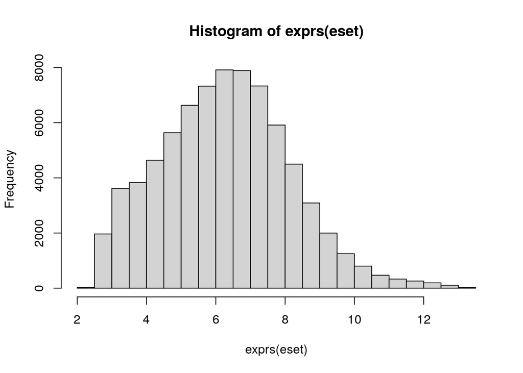

```r
hist(exprs(eset))
```

- Histogram for the std deviation of expression values

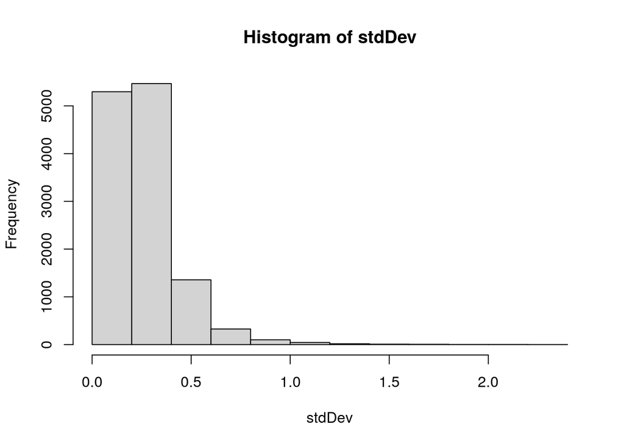

```r
stdDev = apply(exprs(eset), 1, sd)
hist(stdDev)
```

## Experimental design

- Response variable: Expression of genes
- Groups and levels: Group control and group treated
- Type of experimental design: Completely randomized design
- Sample size and number of experimental units per combination of factors: Total sample size of six, three treated and three control

## Comparisons between groups

The comparison I deem more interesting given the study is trated vs. non-treated. So the contrast is going to be : c1 = Treated - Control

## Design matrix and contrast matrix

### Design matrix

```r
design<-matrix(
  c(0, 0, 0, 1, 1, 1, 1, 1, 1, 0, 0 , 0),
  nrow=6,byrow=F)
colnames(design) <- c("Treated", "Control")
rownames(design) <- c("GSM263915","GSM263916", "GSM263917", "GSM263918", "GSM263919", "GSM263920")
print(design)
```

```
##           Treated Control
## GSM263915       0       1
## GSM263916       0       1
## GSM263917       0       1
## GSM263918       1       0
## GSM263919       1       0
## GSM263920       1       0
```

### Contrast matrix

```r
require(limma)
cont.matrix <- makeContrasts (
  c1 = Treated - Control,
  levels=design)
print(cont.matrix)
```

```
##          Contrasts
## Levels    c1
##   Treated  1
##   Control -1
```

## Linear model

Now that we have constructed our matrices let’s fit the data and the matrices to a linear model. Adjusting also for false discovery rates.

```r
require(limma)
fit<-lmFit(eset, design)
fit.main<-contrasts.fit(fit, cont.matrix)
fit.main<-eBayes(fit.main)
topTab_TvsC <- topTable (fit.main, number=nrow(fit.main), coef="c1", adjust="fdr"); head(topTab_TvsC)
```

```
##                    ID   GB_ACC SPOT_ID Species.Scientific.Name Annotation.Date
## 32821_at     32821_at AI762213                    Homo sapiens     Oct 6, 2014
## 988_at         988_at   X16354                    Homo sapiens     Oct 6, 2014
## 1042_at       1042_at   U27185                    Homo sapiens     Oct 6, 2014
## 39016_r_at 39016_r_at   L42611                    Homo sapiens     Oct 6, 2014
## 40071_at     40071_at   U03688                    Homo sapiens     Oct 6, 2014
## 36105_at     36105_at   M18728                    Homo sapiens     Oct 6, 2014
##                 Sequence.Type Sequence.Source
## 32821_at   Consensus sequence         GenBank
## 988_at      Exemplar sequence         GenBank
## 1042_at     Exemplar sequence         GenBank
## 39016_r_at Consensus sequence         GenBank
## 40071_at   Consensus sequence         GenBank
## 36105_at   Consensus sequence         GenBank
##                                                                                                                                               Target.Description
## 32821_at          Cluster Incl. AI762213:wi54d04.x1 Homo sapiens cDNA, 3' end /clone=IMAGE-2394055 /clone_end=3' /gb=AI762213 /gi=5177880 /ug=Hs.204238 /len=677
## 988_at                                       X16354 /FEATURE= /DEFINITION=HSTM1CEA Human mRNA for transmembrane carcinoembryonic antigen BGPa (formerly TM1-CEA)
## 1042_at                                                                     U27185 /FEATURE= /DEFINITION=HSU27185 Human RAR-responsive (TIG1) mRNA, complete cds
## 39016_r_at       Cluster Incl. L42611:Homo sapiens keratin 6 isoform K6e (KRT6E) mRNA, complete cds /cds=(40,1734) /gb=L42611 /gi=908802 /ug=Hs.111758 /len=1986
## 40071_at   Cluster Incl. U03688:Human dioxin-inducible cytochrome P450 (CYP1B1) mRNA, complete cds /cds=(346,1977) /gb=U03688 /gi=501030 /ug=Hs.154654 /len=5102
## 36105_at               Cluster Incl. M18728:Human nonspecific crossreacting antigen mRNA, complete cds /cds=UNKNOWN /gb=M18728 /gi=189084 /ug=Hs.73848 /len=2533
##            Representative.Public.ID
## 32821_at                   AI762213
## 988_at                       X16354
## 1042_at                      U27185
## 39016_r_at                   L42611
## 40071_at                     U03688
## 36105_at                     M18728
##                                                                                                 Gene.Title
## 32821_at                                                                                       lipocalin 2
## 988_at                    carcinoembryonic antigen-related cell adhesion molecule 1 (biliary glycoprotein)
## 1042_at                                            retinoic acid receptor responder (tazarotene induced) 1
## 39016_r_at                                                                                      keratin 6A
## 40071_at                                             cytochrome P450, family 1, subfamily B, polypeptide 1
## 36105_at   carcinoembryonic antigen-related cell adhesion molecule 6 (non-specific cross reacting antigen)
##            Gene.Symbol ENTREZ_GENE_ID
## 32821_at          LCN2           3934
## 988_at         CEACAM1            634
## 1042_at        RARRES1           5918
## 39016_r_at       KRT6A           3853
```

[output cut: 22 more lines]

[output not shown]

```r
write.csv2(topTab_TvsC, file=paste("Selected.Genes.in.comparison.","control_vs_treated",".csv", sep=""))
```

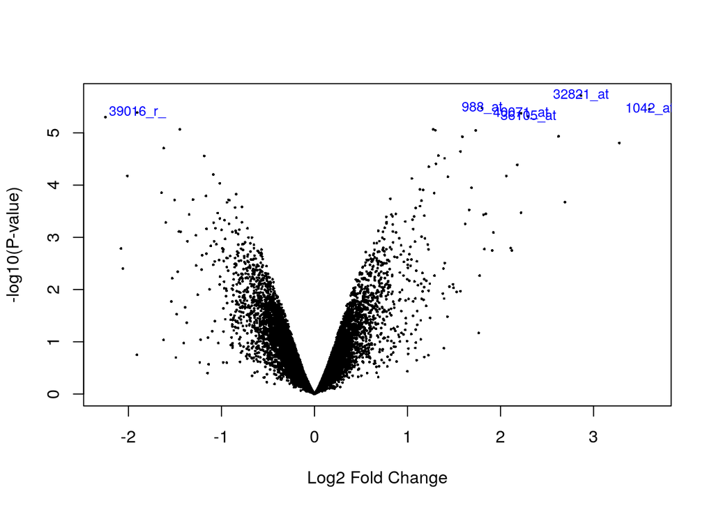

```r
volcanoplot(fit.main, coef="c1", highlight=6)
```

As we can see in the plot the differentialy expressed genes correspond to the probeset identifiers : 32821_at, 1042_at, 988_at, 39016_r_at, 36105_at, 40071_at.